# cRazy-coders-module7

cRazy-coders

2022-11-14

# Introduction

In order to study such a relationship, we will be conducting controlled and fatigued experiments using the human upper limb muscles by lifting a heavy book bag. This will cause the muscles to experience eccentric fatigue, in which the muscles are doing negative work. By undertaking maximum voluntary contractions (MVCs), our group will produce isometric force-angle curves for human forearm flexors. We will then use this data to compare at what angle maximum isometric force for fatigued and non-fatigued forearm flexors.

# Methods

Following data collection, the force-length relationship will be analyzed in two ways. First through the isometric force-angle curves, and second through comparing the angles at which the maximum isometric force occurred between the control and experimental data. The maximum force for each recording was determined and normalized against the control and experimental data. The normalized values then were analyzed to determine if any shifts occurred in maximum force in relation to the angle. Next, the differences in maximum force between the two data sets were found and the mean shifts were calculated.

# Results

```r
dat.norm2 <- dat.norm%>%
  group_by(angle, subject, experiment)%>%
  summarize(max_force_normalized=max_force_recording/max_force_exp)
  print(dat.norm2)
```

```
## # A tibble: 593 × 4
## # Groups:   angle, subject [313]
##    angle subject experiment max_force_normalized
##    <dbl> <chr>   <chr>                     <dbl>
##  1  22.5 27      "control "                0.898
##  2  45   10      "control "                0.872
##  3  45   10      "fatigue "                0.793
##  4  45   14      "control "                0.872
##  5  45   14      "fatigue "                0.797
##  6  45   17      "control "                0.894
##  7  45   17      "fatigue "                0.8
##  8  45   18      "control "                0.872
##  9  45   18      "fatigue "                0.890
## 10  45   19      "control "                0.9
## # … with 583 more rows
```

*Table 1. This table shows all of the data collected by the class.*

The normalized data of the force length relationship is shown below. It is evident that the class data does not follow the normal expected force length relationship.

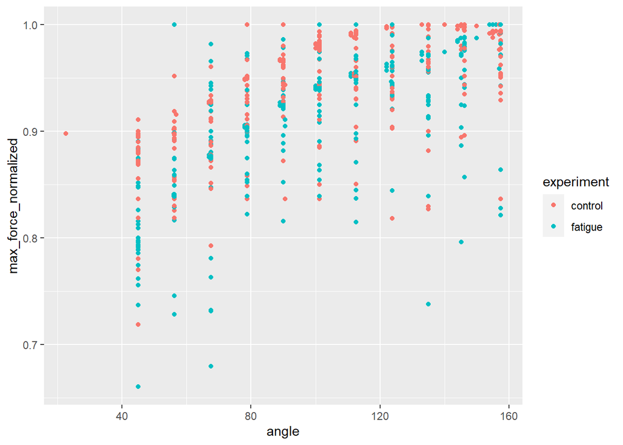

```r
dat.2 <- dat.norm2%>%
  na.omit()

dat.2%>%
  ggplot(aes(angle,max_force_normalized,col=experiment))+geom_point()
```

*Figure 1. Normalized data of force-length relationship in control and fatigued muscles*

Below, we start looking for the model that best fits the data by doing an AIC analysis.

```r
AICs <- dat.norm2%>%
  group_by(subject,experiment)%>%
  summarize(
    m2=AICc(lm(max_force_normalized~poly(angle,2))), #second order
    m3=AICc(lm(max_force_normalized~poly(angle,3))), #third order
    m4=AICc(lm(max_force_normalized~poly(angle,4))) #fourth order
  )%>%
  pivot_longer(m2:m4,names_to="model",values_to="AICc")%>%
  print()
```

```
## # A tibble: 165 × 4
## # Groups:   subject [28]
##    subject experiment model    AICc
##    <chr>   <chr>      <chr>   <dbl>
##  1 1       "control " m2    -130.
##  2 1       "control " m3    -126.
##  3 1       "control " m4    -117.
##  4 1       "fatigue " m2     -87.0
##  5 1       "fatigue " m3     -94.2
##  6 1       "fatigue " m4     -85.6
##  7 10      "control " m2     -70.1
##  8 10      "control " m3     -52.1
##  9 10      "control " m4       3.37
## 10 10      "fatigue " m2     -34.8
## # … with 155 more rows
```

*Table 2. This table contains the AIC values of different models for each subject and experiment type*

```r
x.pred <- seq(45,157.5,length.out = 1000)

fits <- dat.norm2%>%
  group_by(subject,experiment)%>%
  summarize(
    m2=predict(lm(max_force_normalized~poly(angle,2)),newdata=data.frame(angle=x.pred)), #second order
    m3=predict(lm(max_force_normalized~poly(angle,3)),newdata=data.frame(angle=x.pred)), #third order
    m4=predict(lm(max_force_normalized~poly(angle,4)),newdata=data.frame(angle=x.pred)) #fourth order
  )%>%
   pivot_longer(m2:m4,names_to="model")%>%
   group_by(subject,experiment,model)%>%
   summarize(theta_max=x.pred[which.max(value)])%>%
   print()
```

```
## # A tibble: 165 × 4
## # Groups:   subject, experiment [55]
##    subject experiment model theta_max
##    <chr>   <chr>      <chr>     <dbl>
##  1 1       "control " m2         135.
##  2 1       "control " m3         135.
##  3 1       "control " m4         135.
##  4 1       "fatigue " m2         158.
##  5 1       "fatigue " m3         158.
##  6 1       "fatigue " m4         158.
##  7 10      "control " m2         136.
##  8 10      "control " m3         136.
##  9 10      "control " m4         136.
## 10 10      "fatigue " m2         158.
## # … with 155 more rows
```

*Table 3. This table shows the theta max of each model for each subject and experiment type*

```r
best.models <- fits%>%
  left_join(AICs)%>%
  group_by(subject,experiment)%>%
  mutate(best=AICc==min(AICc))%>%
  filter(best==TRUE)%>%
  dplyr::select(-best)%>%
  print()
```

```
## # A tibble: 55 × 5
## # Groups:   subject, experiment [55]
##    subject experiment model theta_max   AICc
##    <chr>   <chr>      <chr>     <dbl>  <dbl>
##  1 1       "control " m2         135. -130.
##  2 1       "fatigue " m3         158.  -94.2
##  3 10      "control " m2         136.  -70.1
##  4 10      "fatigue " m3         158.  -53.9
##  5 14      "control " m2         136. -115.
##  6 14      "fatigue " m3         158.  -75.6
##  7 17      "control " m2         158.  -38.5
##  8 17      "fatigue " m3         158.  -38.4
##  9 18      "control " m2         158.  -27.9
## 10 18      "fatigue " m2         139.  -29.3
## # … with 45 more rows
```

*Table 4. This table is as joined table that shows the best fitting model for each subject and experiment type based on the theta max and AIC value*

We are now able to conduct an anova test with theta max in order to determine the if the differences in theta max values for the control and fatigue groups are statistically significant.

```r
anova(lm(theta_max~experiment,best.models))
```

```
## Analysis of Variance Table
##
## Response: theta_max
##            Df  Sum Sq Mean Sq F value  Pr(>F)
## experiment  1   858.7  858.73  4.1291 0.04718 *
## Residuals  53 11022.3  207.97
## ---
## Signif. codes:  0 '***' 0.001 '**' 0.01 '*' 0.05 '.' 0.1 ' ' 1
```

*Table 5. This table contains the anova values in order to determine if the differences in theta max are significantly different.* As seen in the table above, the Pr value for this anova test is 0.04718, which is less than the significance threshold of 0.05. Therefore, we are able to conclude that there is a significant difference between the theta max values between control and fatigued muscles.

Lastly, we are able to find the average theta shift between the control and fatigue groups.

```r
dat.3 <- best.models%>%
  pivot_wider(id_cols=subject,names_from = experiment, values_from=theta_max)%>%
  print()
```

```
## # A tibble: 28 × 3
## # Groups:   subject [28]
##    subject `control ` `fatigue `
##    <chr>        <dbl>      <dbl>
##  1 1             135.       158.
##  2 10            136.       158.
##  3 14            136.       158.
##  4 17            158.       158.
##  5 18            158.       139.
##  6 19            124.       134.
##  7 2             133.       158.
##  8 21            124.       130.
##  9 22            135.       158.
## 10 23            144.       158.
## # … with 18 more rows
```

```r
dat.3 <- dat.3 %>% mutate(shift= `fatigue `-`control `)%>% #Why do the variable names change like this, it took forever to figure out
  ungroup() %>%
  na.omit()%>%
  summarise(mean.shift=mean(shift),se.shift=sd(shift)/sqrt(length(shift))) %>%
  print()
```

```
## # A tibble: 1 × 2
##   mean.shift se.shift
##        <dbl>    <dbl>
## 1       8.52     4.37
```

*Table 6. This table contains the average theta max shift and contains the SEM values for them as well.*

# Discussion

A graph of the class wide data for the force angle relationship of the human forearm flexors deviates from a normal force-length relationship as there is an increase in maximum force, whereas a bell shaped distribution would normally be seen. As found in M. B. MacNaughton and MacIntosh (2006), there is a rightward shift in the force length relationship after sufficient fatigue. As the muscle was subjected to fatigue, the active force used at a longer muscle length increased from the previous trial that was done prior to the fatigue protocol.

# Author Contributions

Eugene - Results Katherine - Introduction Phoebe - Methods Sabrina - Discussion

M. B. MacNaughton, and B. R. MacIntosh. 2006. “Reports of the Length Dependence of Fatigue Are Greatly Exaggerated.” *Journal of Applied Physiology* 101 (1): 23–29.